# STAT 440: Homework 01

Spring 2021, Anurag Anand

##### Due: Monday, February 8 by 11:30 PM CT

## Exercise 1 (Markdown)

- First Name: Anurag
- Last Name: **Anand**
- Level of Study: MS
- Field of Study: Statistics

## Exercise 2 (Prior knowledge about using Box, Markdown)

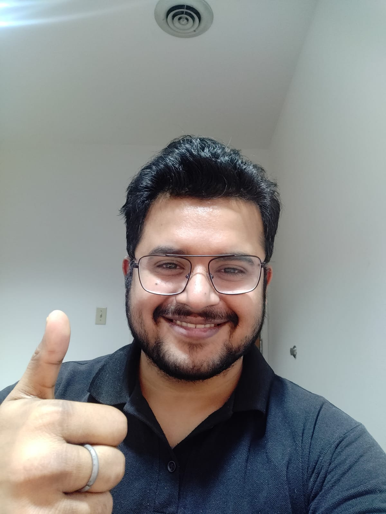

*Anurag Anand*

## Exercise 3 (Syllabus, Markdown)

**(a)** Are students allowed to work together on homework assignments?

- Yes, we can share ideas and help each other in resolving roadblocks

**(b)** Are students allowed to Share code?

- No, sharing of code is not allowed

**(c)** What is the “rule of thumb” that I offer to help you maintain academic integrity while completing homework?

- Share ideas, not code

## Exercise 4 (Compass, Markdown)

**(a)** In an unordered list, give the names of the teaching assistants (TAs) for this course?

- Diptarka Saha (DS)

**(b)** Which days of the week are Online Office Hours available from the TAs or Instructor?

- Mondays: 8pm-10pm (DS)
- Wednesdays: 8pm-10pm (DS)
- Thursdays: 8pm-10pm (DS)

## Exercise 5 (Prior knowledge about software, Markdown)

1. R
2. Python
3. SAS

## Exercise 6 (Prior knowledge about data, Markdown)

Three things that I know about the data:

- It is a crossword of animal names
- The crossword is completely filled
- There are animal drawings in the image

Three things that I want to know about the data:

- Frequency count of each alphabet constituting the animal’s name
- Number of distinct animals
- Assign a label to each animal (vertical / horizontal), depending on how it is filled in the crossword

## Exercise 7 (Prior knowledge about data, Markdown)

| Alphabet | Frequency |
| --- | --- |
| A | $N_a$ |
| B | $N_b$ |
| C | $N_c$ |
| D | $N_d$ |
| E | $N_e$ |

## Exercise 8 (Prior knowledge about data, Markdown)

Three things that I know about the data:

- The image contains a scarf
- The scarf is lying on the floor, unrolled
- The scarf is made of three distinct colors

Three things that I want to know about the data:

- What does each color represent ?
- What does the thickness of each colored band represent ?
- How is the total length of the scarf split across the three different colors ?

## Exercise 9 (Prior knowledge about data, Markdown)

| Band_Number (Left to right) | Band_Color | Thickness |
| --- | --- | --- |
| Band1 | Grey | $t_1$ |
| Band2 | Pink | $t_2$ |
| Band3 | Red | $t_3$ |

## Exercise 10 (Prior knowledge about data, Markdown)

- A kind of data analysis that is sensible for this data set?
  - Frequecny plot of the three colors that are appearing on the band
- What information is needed to help improve the data so that more analysis can be done?
  - If we get to know what does each color represent and which process decided the thickness of each band we can do additional analysis